# Assignment 1

Kunal Sharma

## Importing Important Packages

```r
library(ISLR)
library(dplyr)
library(ggplot2)
```

Loading the Carseats dataset with only 3 variables. Filtering the data into two subsets based on the shelve location(GOOD or BAD).

```r
SafeBabies <- Carseats %>% select("Sales", "Price", "ShelveLoc")
Good_shevles <- filter(SafeBabies, ShelveLoc == "Good")
Bad_shevles <- filter(SafeBabies, ShelveLoc == "Bad")
```

#Building a Linear Regression model to predict the sales of the carseat for both good as well as bad shelve location individually.

```r
#Linear Model for GOOD Shelve location
Lm_Good <- lm(Sales ~ Price, data = Good_shevles)
summary(Lm_Good)
```

```
##
## Call:
## lm(formula = Sales ~ Price, data = Good_shevles)
##
## Residuals:
##    Min     1Q Median     3Q    Max
## -3.721 -1.351 -0.098  1.483  4.353
##
## Coefficients:
##              Estimate Std. Error t value Pr(>|t|)
## (Intercept) 17.968864   0.988008  18.187  < 2e-16 ***
## Price       -0.065785   0.008199  -8.023 5.85e-12 ***
## ---
## Signif. codes:  0 '***' 0.001 '**' 0.01 '*' 0.05 '.' 0.1 ' ' 1
##
## Residual standard error: 1.888 on 83 degrees of freedom
## Multiple R-squared:  0.4368, Adjusted R-squared:   0.43
## F-statistic: 64.37 on 1 and 83 DF,  p-value: 5.848e-12
```

```r
#Linear Model for BAD Shelve location
Lm_Bad <- lm(Sales ~ Price, data = Bad_shevles)
summary(Lm_Bad)
```

```
##
## Call:
## lm(formula = Sales ~ Price, data = Bad_shevles)
##
## Residuals:
##     Min      1Q  Median      3Q     Max
## -4.4622 -1.0617 -0.2014  1.2050  4.6412
##
## Coefficients:
##              Estimate Std. Error t value Pr(>|t|)
## (Intercept) 11.832984   0.990317  11.949  < 2e-16 ***
## Price       -0.055220   0.008486  -6.507  3.7e-09 ***
## ---
## Signif. codes:  0 '***' 0.001 '**' 0.01 '*' 0.05 '.' 0.1 ' ' 1
##
## Residual standard error: 1.967 on 94 degrees of freedom
## Multiple R-squared:  0.3105, Adjusted R-squared:  0.3032
## F-statistic: 42.34 on 1 and 94 DF,  p-value: 3.702e-09
```

#Equation: Total Profit = Sales * (Selling Price - Production Cost)

Futher simplication of equation we got the below formula,

Assuming the Production Cost of a CarSeat is $55.0, below is the predicted optimal Selling Price of the Carseat.

## optimal cost for shelve location Good

```r
Productioncost<-55
paste("The optimal price for a good shelf position", ((-Lm_Good$coefficients[[2]] *Productioncost) + (Lm_Good$coefficients[[1]]))/(-2 * Lm_Good$coefficients[[2]]))
```

```
## [1] "The optimal price for a good shelf position 164.07312564386"
```

## optimal cost for shelve location bad

```r
paste("The optimal price for a bad shelf position", ((-Lm_Bad$coefficients[[2]] *Productioncost) + (Lm_Bad$coefficients[[1]]))/(-2 * Lm_Bad$coefficients[[2]]))
```

```
## [1] "The optimal price for a bad shelf position 134.643464696399"
```

Note: The negative sign is inserted in the denominator to nullify the negation, as the sign of the LM shows Price’s negative correlation with the intercept (Sales).

```r
Good_Optimal_price_Range <- (predict(Lm_Good, data.frame(Price = c(40:85)))) / (-2*Lm_Good$coefficients[2])
Bad_Optimal_Price_Range <- (predict(Lm_Bad, data.frame(Price = c(40:85)))) / (-2*Lm_Bad$coefficients[2])
```

```r
Price_Range<- cbind.data.frame(Production_Cost = c(40:85), Selling_Price_Good = Good_Optimal_price_Range, Selling_Price_Bad = Bad_Optimal_Price_Range)
Price_Range
```

|  | Production_Cost | Selling_Price_Good | Selling_Price_Bad |
| --- | --- | --- | --- |
| 1 | 40 | 116.57313 | 87.14346 |
| 2 | 41 | 116.07313 | 86.64346 |
| 3 | 42 | 115.57313 | 86.14346 |
| 4 | 43 | 115.07313 | 85.64346 |
| 5 | 44 | 114.57313 | 85.14346 |
| 6 | 45 | 114.07313 | 84.64346 |
| 7 | 46 | 113.57313 | 84.14346 |
| 8 | 47 | 113.07313 | 83.64346 |
| 9 | 48 | 112.57313 | 83.14346 |
| 10 | 49 | 112.07313 | 82.64346 |

[output cut: 36 more lines]

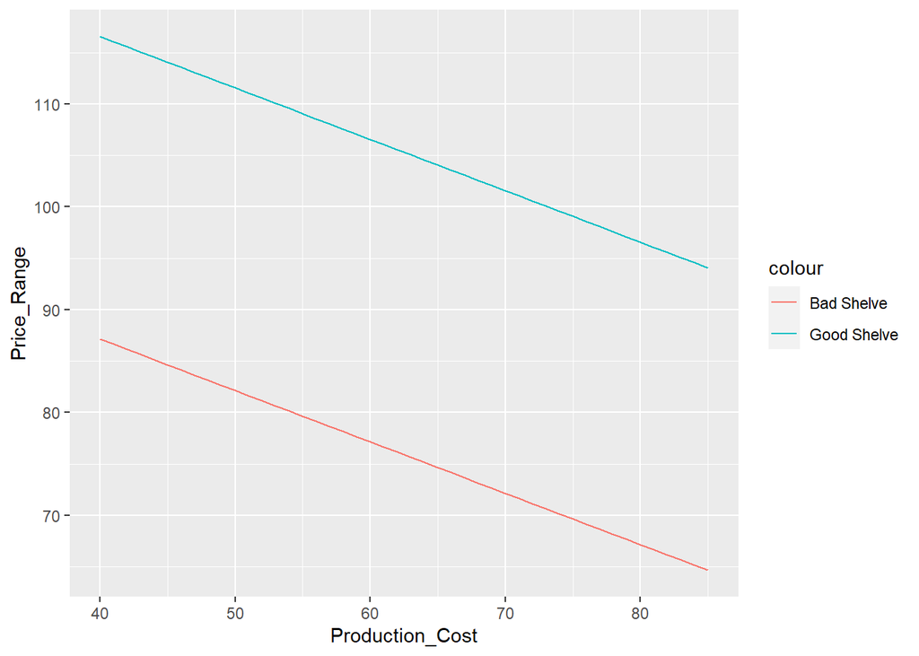

```r
ggplot(Price_Range, aes(Production_Cost, Price_Range)) + geom_line(aes(y = Good_Optimal_price_Range, col = "Good Shelve")) + geom_line(aes(y = Bad_Optimal_Price_Range, col = "Bad Shelve"))
```